# A comparative analysis of AquaMaps and IUCN species distribution maps

JA, CO, BH

## 0.1 Significance

# 1 Introduction

Climate change, ocean temperature rise, ocean acidification, sea ice loss, human impacts from fishing and introduction of nonnative species are likely to significantly alter the global distribution of marine species - but how well do we really understand the current distribution? Understanding species abundances and distributions is a critical component to assessing global biodiversity and detecting patterns and trends through time.

To better understand the similarities and differences between the two data collections, we examined three fundamental questions:

- How do the two spatial data collections compare in their representation of global spatial distribution of species diversity?
- How do the two spatial data collections compare in their representation of species diversity across taxonomic groups?
- For species represented in both collections, how closely do the spatial distribution maps align?

The Ocean Health Index and MPA Gap Analysis study both provide case studies examined the implications of alternate data use scenarios on two large-scale studies of global biodiversity and conservation.

# 2 Understanding each dataset separately

The IUCN publishes species distribution maps for as collections of shapefiles for a range of taxonomic groups, including both terrestrial and marine organisms. Species spatial distributions are determined by experts based upon known occurrences of the species and expert understanding of range and habitat preferences. These maps are typically based on species occurrence records from databases such as *OBIS* and *GBIF*; IUCN provides general guidelines to facilitate consistency in how the maps are generated. The IUCN presents these maps as ‘limits of distribution’; they are meant to indicate that a species probably occurs within the defined polygon, but are not meant to indicate that the species is evenly distributed within the polygon. While the polygons roughly define regions of presence/absence, additional attributes provide information on extant/extinct ranges, native/introduced ranges, and seasonality.

IUCN publishes spatial distribution map sets only for taxonomic groups that have been “comprehensively assessed,” i.e. in which at least 90% of the species within the taxonomic group have been evaluated. While this mitigates sampling bias within taxa, it also means that entire taxonomic groups remain unavailable until they have met this threshold of comprehensive assessment. As of December 2015, IUCN had published species distribution maps for nearly 4500 marine species across 24 taxonomic groups. (For this analysis, we did not consider IUCN range maps for bird species, as those data are hosted separately by BirdLife International.)

# 3 Methods

## 3.1 Analysis of taxonomic and regional inclusion

### 3.1.1 Overlap between assessed species

Due to differences in both methodology and intent, there are significant differences in the coverage afforded by the species distribution maps published by AquaMaps and those published by the IUCN. This is immediately clear from an examination of the number of species maps offered by each source, and the small proportion of species with maps from both sources.

| Map set | n<sub>total</sub> | n<sub>Red_List</sub> |
| --- | --- | --- |
| AquaMaps | 22889 | 5246 |
| IUCN | 4343 | all |
| Both | 2455 | all |

### 3.1.2 Taxonomic distribution between data collections

Studies of species richness and biodiversity depend on sampling a representative cross section of ecosystems, and thus benefit from a broad representation across taxonomic groups. To examine the overall taxonomic distribution across the spatial data collections, we grouped species by taxonomic class and data source (IUCN, AquaMaps, or both), and examined the proportion of each class represented in each data source category. Since biodiversity studies often rely on both spatial distribution and indicators of species health, we further divided the data by whether species had been evaluated for the IUCN Red List of Threatened Species.

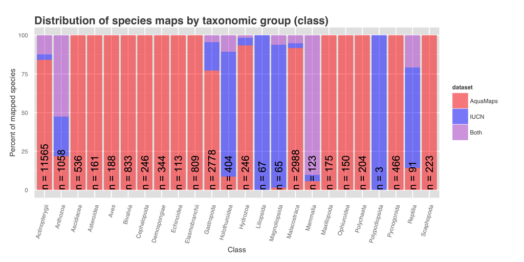

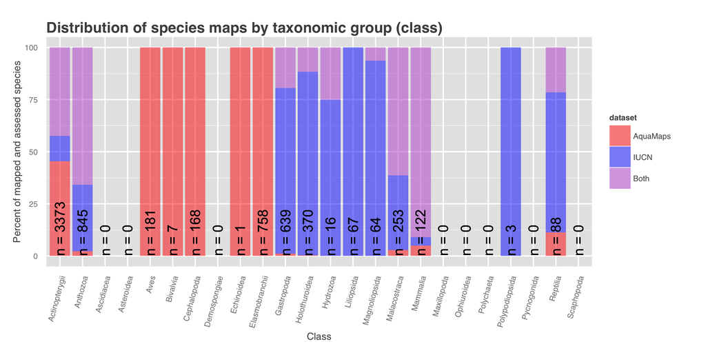

The IUCN only releases spatial data sets when a taxonomic group (on the scale of order or family) has been comprehensively assessed. As such, spatial data for many taxonomic classes are unavailable, and within a class, the assessed sub-groups may not represent the entire class. For example, as of this writing, IUCN has released no spatial data for class Elasmobranchii (cartilaginous fishes including sharks and rays); and while IUCN offers a large number of maps within class Actinopterygii (ray-finned bony fishes), the available maps include only a few primarily tropical taxonomic sub-groups, such as wrasses, damselfish, butterflyfish, tunas, and billfishes, but are missing economically important subgroups including salmon, rockfish, and clupeids. However, IUCN’s criterion of comprehensive assessment greatly reduces the risk of sample bias within the bounds of the assessed taxonomic groups.

The release of AquaMaps distribution maps is not limited to comprehensively-assessed taxa, and maps are available across a much larger range of taxonomic classes; however, there is no guarantee that the list of species included within each class is a representative cross section of the entire class.

Some global-scale studies of biodiversity, such as the Ocean Health Index, require both spatial distribution information and non-spatial information such as extinction risk, population trend, or native/non-native status provided by IUCN Red List assessments. While all species represented in IUCN distribution maps have also been evaluated for Red List inclusion, we found that only 22.9% (5246 of 22889) of AquaMaps species have been similarly evaluated, severely limiting the catalog of available species maps for studies of biodiversity and ecosystem health.

Broad taxonomic inclusion is critical for understanding distribution and health of ecosystems at any spatial scale, but global and large regional studies of species diversity also require representative sampling across regions. To compare the spatial representation of the two data collections directly, we first rasterized the IUCN species polygons to the same 0.5° cells as the AquaMaps species maps; species presence within a cell was determined by any non-zero overlap of a species polygon with the cell, and species richness per cell was simply the sum of the species present. For the AquaMaps data collection, we determined per-cell species richness by summing all species with non-zero probability of occurrence. We represented relative distribution of species richness for each data collection by plotting average species count against latitude and longitude. To highlight the differences between the two data collections, we also examined the relative difference in per-cell species richness against latitude and longitude.

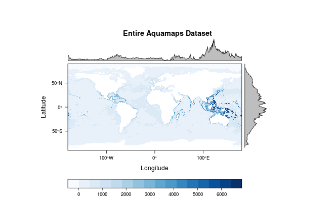

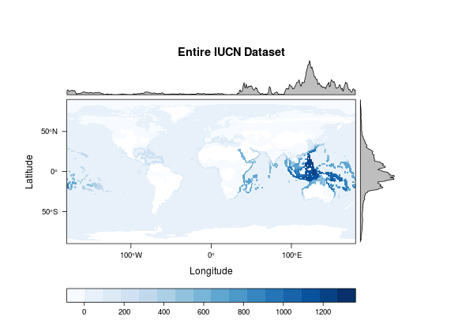

## 3.2 Analysis of spatial alignment by species

### 3.2.1 Defining spatial alignment between the two data collections

For species described in both spatial data collections, we would expect to see some spatial correlation, both in the global pattern of species distribution and the extent of species range. Large discrepancies in distribution and range area could indicate species that require further study to consolidate expert knowledge and improve species distribution models.

Overlaying distribution maps from the two data sets for a given species, we calculated two dimensions of spatial alignment: *distribution alignment*, which we defined as the ratio of the smaller range that overlapped with the larger range; and *area alignment*, which we defined as the ratio of the smaller range to the larger range.

$Match_{area} = \frac{A_{smaller}}{A_{larger}} * 100\%$

For a species whose distribution is well understood, and whose range is described in both data collections, we would expect to see a value near 100% for each dimension of alignment, indicating near-total inclusion of the smaller range within the larger (*distribution alignment*) and very similar extent of range (*area alignment*).

For each of the 2234 species whose range is described by both data collections, we calculated the distribution alignment and the area alignment, and plotted the species map pairs on a scatter plot of distribution alignment vs area alignment (Figure 1).

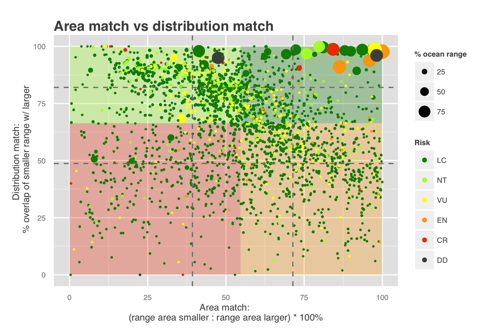

We divided the plot into quadrants based on the median values for each axis to differentiate between four different qualities of alignment:

[output not shown]

*The upper right quadrant (quadrant 1) comprises species whose maps largely agree (better than median value) in both spatial distribution and the area of described ranges. For these species, the expert-drawn range map and the bioclimatic envelope model produce similar predictions of species distribution. (n = 407; 18.2 %)* The other quadrants each suggest a different story. Species map pairs that fall within the upper left quadrant (quadrant 2: well-matched in distribution but poorly-matched in area) indicate species in which the range of the smaller map falls generally within the larger map, but the larger map may include more generous buffers or may include areas unrepresented in the smaller map. (n = 708; 31.7 %) *The lower right quadrant (quadrant 3: well-matched in area but poorly matched in distribution) includes species for which the two maps generally agree in range area, but disagree in where those ranges occur. Disagreement in distribution seems to indicate a greater issue than disagreement in area extent, so we categorized map pairs in this quadrant as being more problematic than map pairs in either of the upper quadrants. (n = 706; 31.6 %)* The lower left quadrant (quadrant 4: poorly matched in both dimensions) indicates species for which the map pairs fail to agree in both area and distribution. (n = 413; 18.5 %)

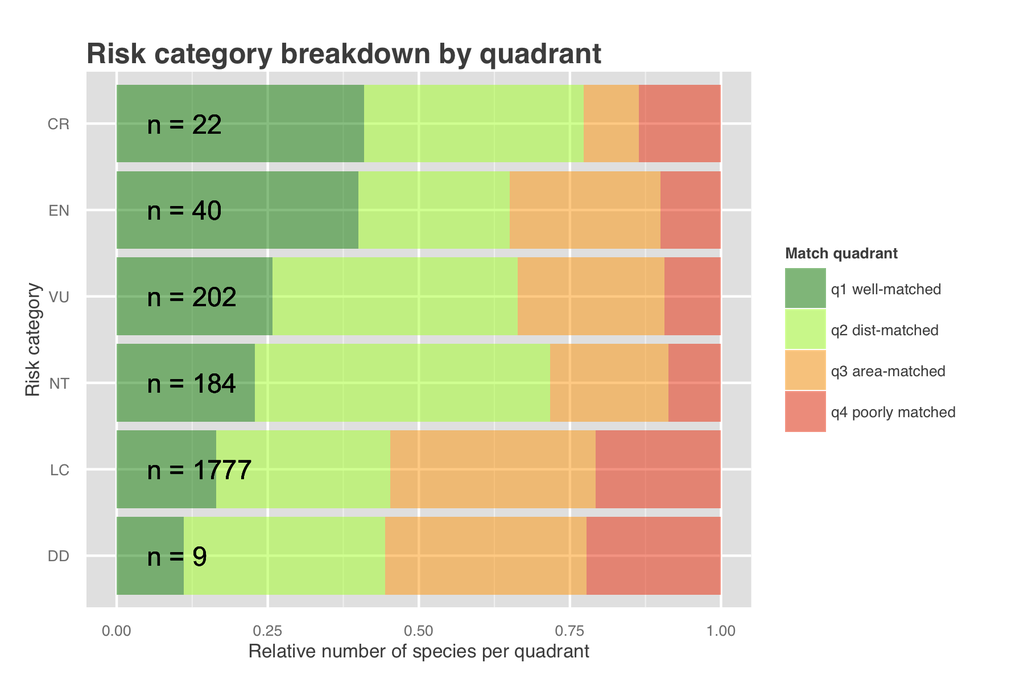

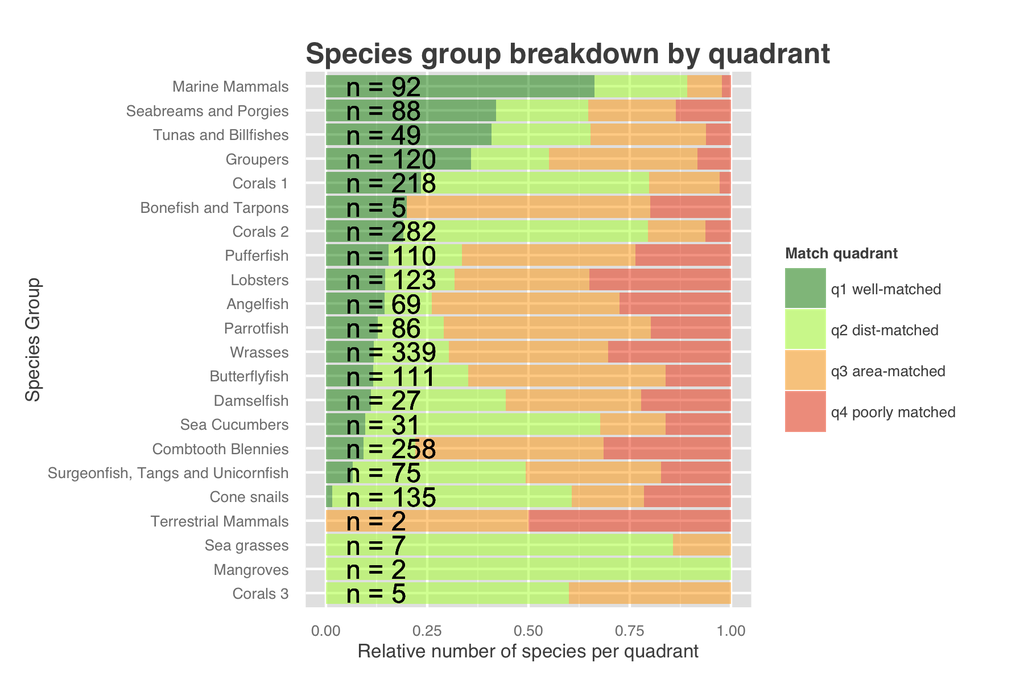

Breaking down the quadrants by IUCN extinction risk categories, species with higher extinction risk tend to be better matched between the two data collections; this is not surprising, as these at-risk species are likely to face closer expert scrutiny than species ranked as Least Concern.

## 3.3 AquaMaps: Effect of changing “presence” threshold on area representation

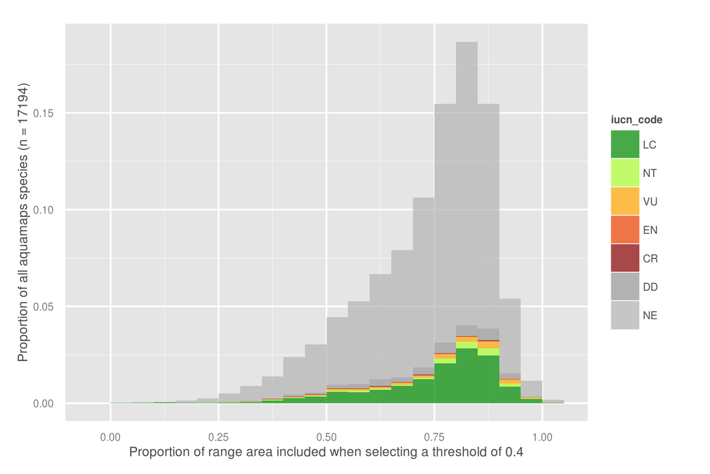

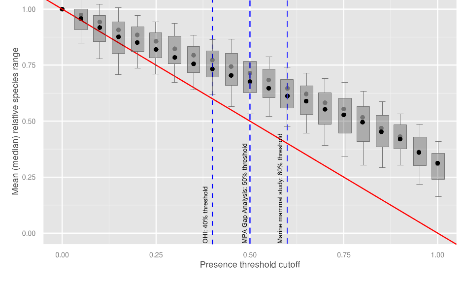